# DV5

Author

Wayne Frederick II

```r
library(tidyverse)
# Read in the data
wncaa <- read_csv("https://raw.githubusercontent.com/vaiseys/dav-course/main/Data/wncaa.csv")
# Glimpse the data
glimpse(wncaa)
```

```
Rows: 2,092
Columns: 19
$ year              <dbl> 1982, 1982, 1982, 1982, 1982, 1982, 1982, 1982, 1982…
$ school            <chr> "Arizona St.", "Auburn", "Cheyney", "Clemson", "Drak…
$ seed              <dbl> 4, 7, 2, 5, 4, 6, 5, 8, 7, 7, 4, 8, 2, 1, 1, 2, 3, 6…
$ conference        <chr> "Western Collegiate", "Southeastern", "Independent",…
$ conf_w            <dbl> NA, NA, NA, 6, NA, NA, NA, NA, NA, NA, NA, NA, NA, N…
$ conf_l            <dbl> NA, NA, NA, 3, NA, NA, NA, NA, NA, NA, NA, NA, NA, N…
$ conf_percent      <dbl> NA, NA, NA, 66.7, NA, NA, NA, NA, NA, NA, NA, NA, NA…
$ conf_place        <chr> "-", "-", "-", "4th", "-", "-", "-", "-", "-", "-", …
$ reg_w             <dbl> 23, 24, 24, 20, 26, 19, 21, 14, 21, 28, 24, 17, 22, …
$ reg_l             <dbl> 6, 4, 2, 11, 6, 7, 8, 10, 8, 7, 5, 13, 7, 5, 1, 6, 4…
$ reg_percent       <dbl> 79.3, 85.7, 92.3, 64.5, 81.3, 73.1, 72.4, 58.3, 72.4…
$ how_qual          <chr> "at-large", "at-large", "at-large", "at-large", "aut…
$ x1st_game_at_home <chr> "Y", "N", "Y", "N", "Y", "N", "N", "N", "N", "N", "Y…
$ tourney_w         <dbl> 1, 0, 4, 0, 2, 0, 0, 0, 0, 0, 2, 0, 2, 1, 5, 3, 1, 1…
$ tourney_l         <dbl> 1, 1, 1, 1, 1, 1, 1, 1, 1, 1, 1, 1, 1, 1, 0, 1, 1, 1…
$ tourney_finish    <chr> "RSF", "1st", "N2nd", "1st", "RF", "1st", "1st", "1s…
$ full_w            <dbl> 24, 24, 28, 20, 28, 19, 21, 14, 21, 28, 26, 17, 24, …
$ full_l            <dbl> 7, 5, 3, 12, 7, 8, 9, 11, 9, 8, 6, 14, 8, 6, 1, 7, 5…
$ full_percent      <dbl> 77.4, 82.8, 90.3, 62.5, 80.0, 70.4, 70.0, 56.0, 70.0…
```

```r
view(wncaa)
```

## Question 1

```r
champs <- wncaa %>%
  filter(tourney_finish == "Champ")
```

```r
percentwins <- champs %>%
  group_by(school) %>%
  summarise(N = n()) %>%
  mutate(percent = N / sum(N),  pct = round((percent*100), 0))

percentwins
```

```
# A tibble: 15 × 4
   school                  N percent   pct
   <chr>               <int>   <dbl> <dbl>
 1 Baylor                  2  0.0541     5
 2 Louisiana Tech          2  0.0541     5
 3 Maryland                1  0.0270     3
 4 North Carolina          1  0.0270     3
 5 Notre Dame              2  0.0541     5
 6 Old Dominion            1  0.0270     3
 7 Purdue                  1  0.0270     3
 8 South Carolina          1  0.0270     3
 9 Southern California     2  0.0541     5
10 Stanford                2  0.0541     5
11 Tennessee               8  0.216     22
12 Texas                   1  0.0270     3
13 Texas A&M               1  0.0270     3
14 Texas Tech              1  0.0270     3
15 UConn                  11  0.297     30
```

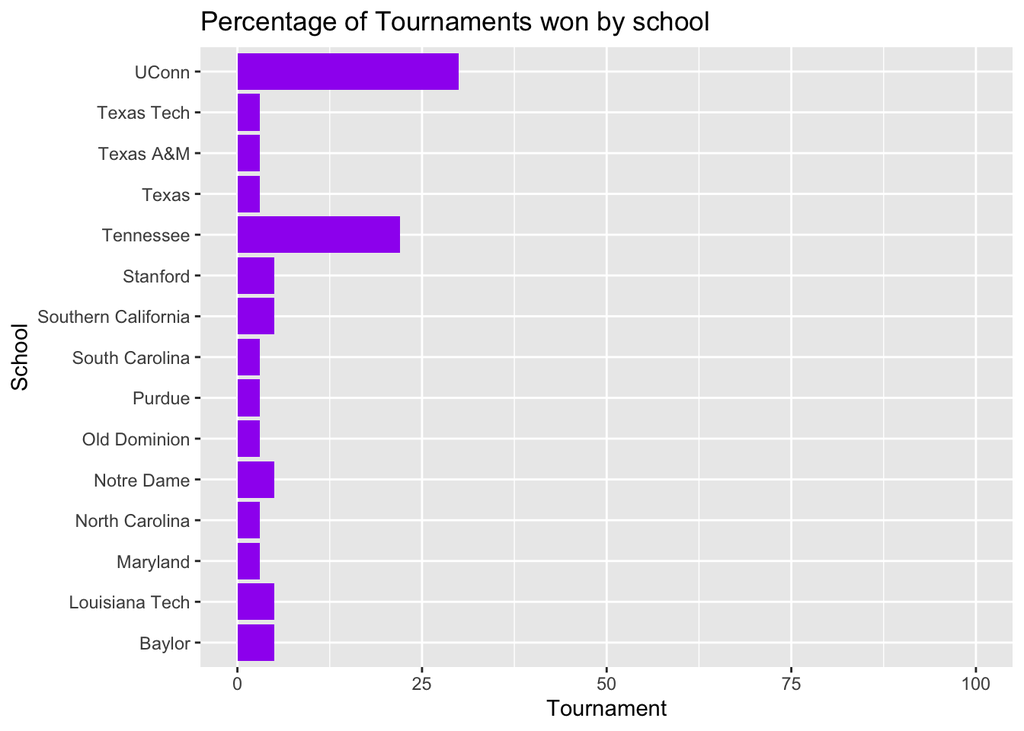

```r
ggplot(percentwins,
       mapping = aes(x = school, y = pct)) +
  geom_col(position = "dodge2", fill = "purple") +
  scale_y_continuous(limits = c(0, 100)) +
  coord_flip() + labs(title = "Percentage of Tournaments won by school", x = "School", y = "Tournament" )
```

UConn and Tennessee have the highest percentage of wins.

## Question 2

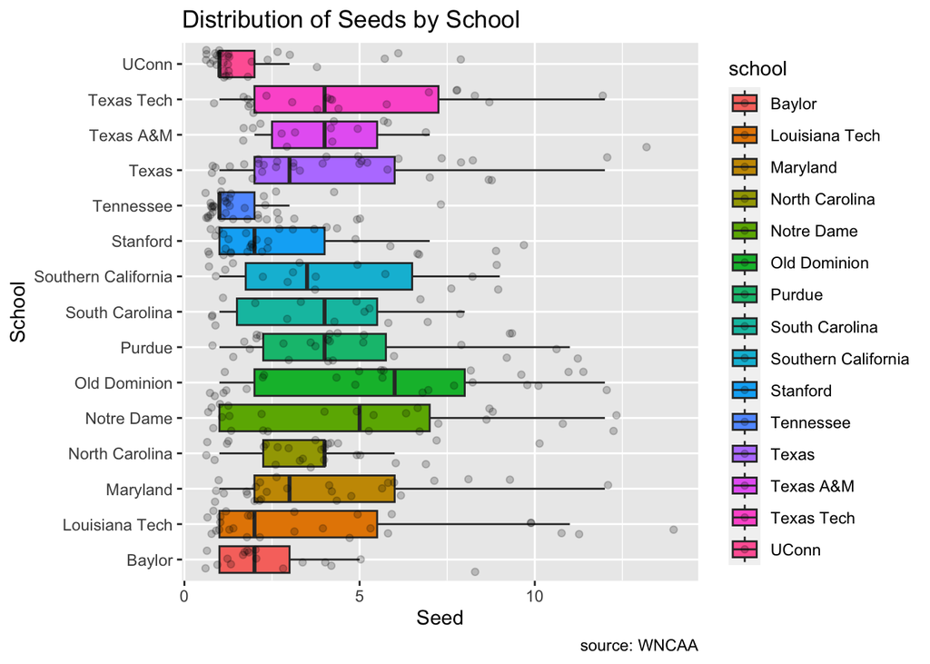

```r
thechamps <- unique(champs$school)

winners <- wncaa %>%
  filter(school %in% thechamps)

ggplot(winners, mapping = aes(x = school, y = seed,  fill = school)) + geom_boxplot(outlier.shape = NA) + geom_jitter(alpha = 0.2) + coord_flip() + labs(title = "Distribution of Seeds by School", x = "School", y = "Seed", caption = "source: WNCAA")
```

The boxplot shows the distribution of seeds by schools that have won a championship. Now to make it easier to interpret, I am reordering the data from lowest average seeds to highest average seeds.

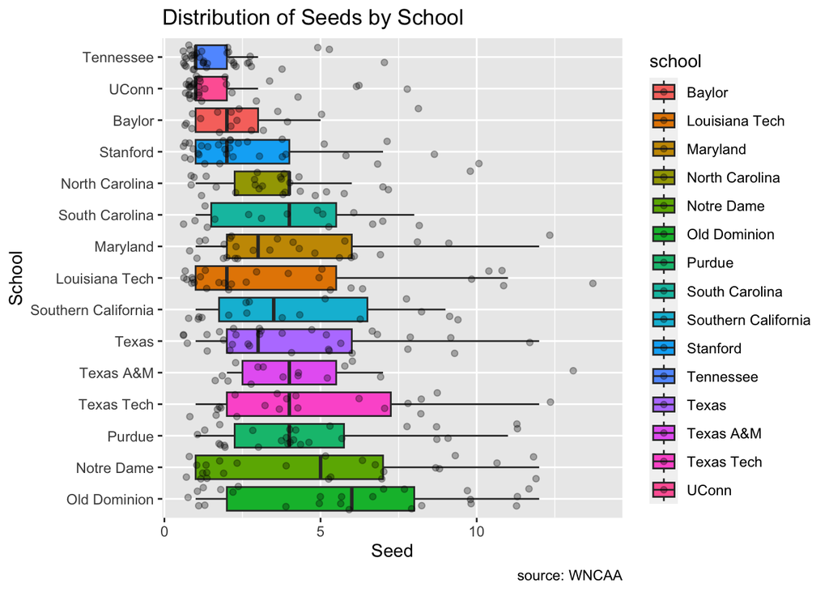

```r
winners <- winners |>
  group_by(school) %>%
  mutate(mean_seed = mean(seed)) %>%
  ungroup()

ggplot(winners,
       aes(x = reorder(school, -mean_seed), y = seed, fill = school)) + geom_boxplot(outlier.shape = NA) + geom_jitter(alpha = 0.3) + coord_flip() + labs(title = "Distribution of Seeds by School", x = "School", y = "Seed", caption = "source: WNCAA")
```

Tennessee and UConn were averaging the 1 seed so it makes sense that they have the best tournament win percentage.

I am now using geom_violin() to visualize the data.

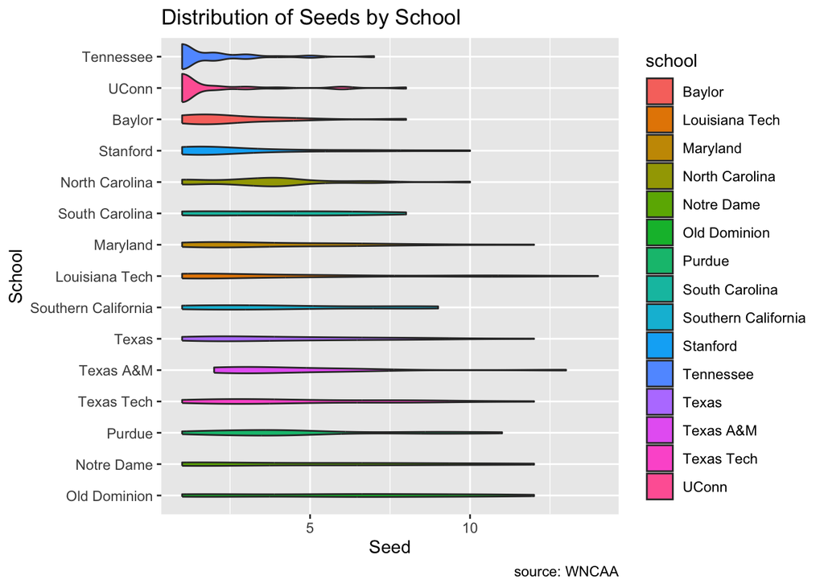

```r
ggplot(winners,
       aes(x = reorder(school, -mean_seed), y = seed, fill = school)) +
  geom_violin() +
  coord_flip() +
  labs(title = "Distribution of Seeds by School", x = "School", y = "Seed", caption = "source: WNCAA")
```

I think the graph with the boxplots tells more because the distribution of data is more clear. The violin graph is hard to read because a lot of them are in the same range so they are hard to tell apart.

## Question 3

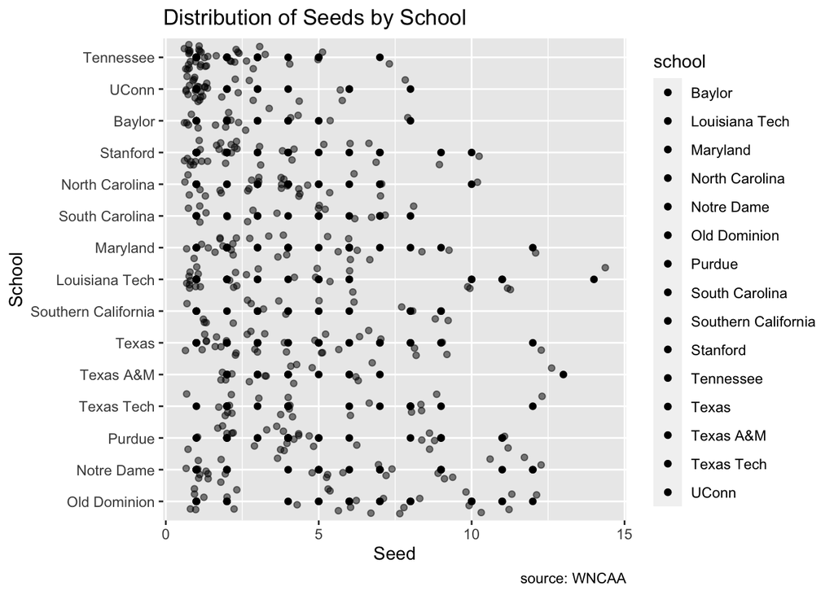

```r
ggplot(winners,
       aes(x = reorder(school, -mean_seed), y = seed, fill = school)) +
  geom_point() +
  geom_jitter(alpha = 0.5) +
  coord_flip() +
  labs(title = "Distribution of Seeds by School", x = "School", y = "Seed", caption = "source: WNCAA")
```

The scatterplot does not show the medians, ranges outlies, or distributions well.

## Question 4

```r
winners_mean_sd <- winners |>
  group_by(school) |>
  summarize(across(where(is.numeric),
                   list(mean = mean,
                        sd = sd)))
```

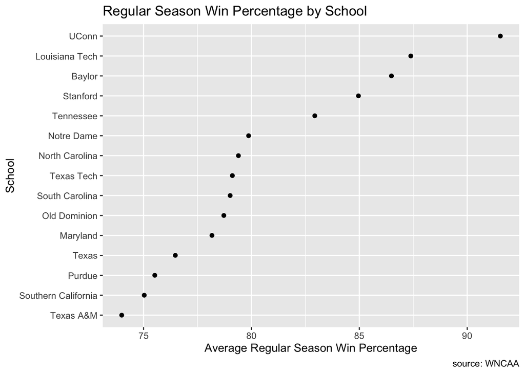

```r
ggplot(winners_mean_sd,
        mapping = aes(x = reorder(school, reg_percent_mean, na.rm = TRUE),
                      y = reg_percent_mean)) +
  geom_point() +
  coord_flip() +
  labs(title = "Regular Season Win Percentage by School", x = "School", y = "Average Regular Season Win Percentage", caption = "source: WNCAA")
```

THis graph shows that the highest average regular season win percentage was Uconn at 91.54%. THe lowest was Texas A&M with 73.99%. Most of the data points are around 77-80%.

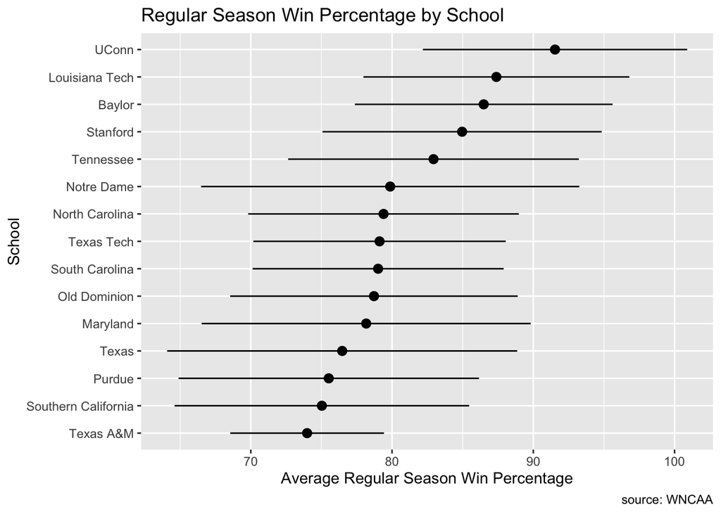

```r
ggplot(winners_mean_sd,
        mapping = aes(x = reorder(school, reg_percent_mean, na.rm = TRUE),
                      y = reg_percent_mean)) +
  geom_pointrange(mapping = aes(ymin = reg_percent_mean - reg_percent_sd,
       ymax = reg_percent_mean + reg_percent_sd)) +
  coord_flip() +
  labs(title = "Regular Season Win Percentage by School", x = "School", y = "Average Regular Season Win Percentage", caption = "source: WNCAA")
```

This shows the standard deviation. The school with the. lowest one is Texas A&M. They have the least variation. The schools hover around 67-80%.

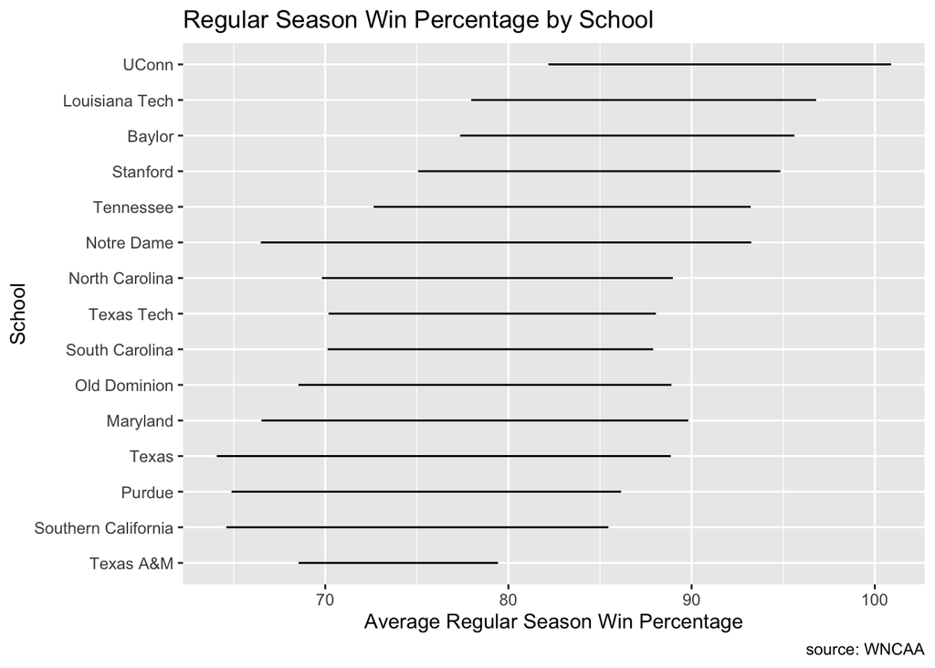

```r
ggplot(winners_mean_sd,
        mapping = aes(x = reorder(school, reg_percent_mean, na.rm = TRUE),
                      y = reg_percent_mean)) +
  geom_linerange(mapping = aes(ymin = reg_percent_mean - reg_percent_sd,
       ymax = reg_percent_mean + reg_percent_sd)) +
  coord_flip() +
  labs(title = "Regular Season Win Percentage by School", x = "School", y = "Average Regular Season Win Percentage", caption = "source: WNCAA")
```

This graph also shows the standard deviation. The mean is not visible on this graph like it is on the previous one.